# Chapter 6: Linear Model Selection and Regularization (Lecture 2)

Spring 2020

## Previous lecture

## Subset selection and shrinkage methods

- Subset selection and shrinkage methods have controlled variance in two ways:
  - Using a subset of the original predictors.
  - Shrinking their coefficients towards zero.
- Those methods use the original (possibly standardized) predictors \(X_1\), …, \(X_p\).

## Dimension reduction methods

## Dimension reduction methods

- Transform the original predictors

\[ Z_m = \sum_{j=1}^{p} \phi_{jm} X_j\] for \(m=1, ..., M\), \(j=1, ..., p\) and \(M < p\)

## Dimension reduction methods

- Transform the original predictors

\[ Z_m = \sum_{j=1}^{p} \phi_{jm} X_j\] for \(m=1, ..., M\), \(j=1, ..., p\) and \(M < p\)

- Fit least square using the transformed predictors

\[ y_i = \theta _0 + \sum_{m=1}^{M} \theta_m z_{im} + \epsilon _i, \quad i=1,...,n\]

## Constrained interpretation

- It can be shown that

\[ \beta_j = \sum_{m=1}^{M} \theta_m \phi_{jm}\]

## Constrained interpretation

- It can be shown that

\[ \beta_j = \sum_{m=1}^{M} \theta_m \phi_{jm}\]

- So dimension reduction serves to constrain the coefficients of a standard linear regression
- This constrain increase the bias but is useful in situations where the variance is high

## Outline

- We will cover two approaches to dimensionality reduction:
  - Principal Components
  - Partial Least Squares

## Principal Component Analysis (PCA)

## Principal Component Analysis (PCA)

- Discussed in greater detail in Chapter 10 about unsupervised learning
- Focus in this lecture is how it can be applied for regression.
  - That is, in a supervised setting.

## Principal Component Analysis (PCA)

- Discussed in greater detail in Chapter 10 about unsupervised learning
- Focus in this lecture is how it can be applied for regression.
  - That is, in a supervised setting.
- PCA is a (unsupervised) technique for reducing the dimension of a \(n \times p\) data matrix \(X\).

## Principal Component Analysis (PCA)

- We want to create a \(n \times M\) matrix \(Z\), with \(M < p\).
- The column \(Z_m\) of \(Z\) is the \(m\)-th principal component.

\[Z_m = \sum_{j=1}^{p} \phi_{jm} X_j \quad \text{subject to} \quad \sum_{j=1}^p \phi_{jm}^2 = 1\]

## Principal Component Analysis (PCA)

- We want to create a \(n \times M\) matrix \(Z\), with \(M < p\).
- The column \(Z_m\) of \(Z\) is the \(m\)-th principal component.

\[Z_m = \sum_{j=1}^{p} \phi_{jm} X_j \quad \text{subject to} \quad \sum_{j=1}^p \phi_{jm}^2 = 1\]

- We want \(Z_1\) to have the highest possible variance.
  - That is, take the direction of the data where the observations vary the most.
  - Without the constrain we could get higher variance by increasing \(\boldsymbol \phi_j\)

## Principal Component Analysis (PCA)

- \(Z_2\) should be uncorrelated to \(Z_1\), and have the highest variance, subject to this constrain.
  - The direction of \(Z_1\) must be perpendicular (or orthogonal) to the direction of \(Z_2\)

## Principal Component Analysis (PCA)

- \(Z_2\) should be uncorrelated to \(Z_1\), and have the highest variance, subject to this constrain.
  - The direction of \(Z_1\) must be perpendicular (or orthogonal) to the direction of \(Z_2\)
- And so on …
- We can construct up to \(p\) PCs that way.
  - In which case we have captured all the variability contained in the data
  - We have created a set of orthogonal predictors
  - But have **not** accomplished dimensionality reduction

## PCA Example - Ad spending

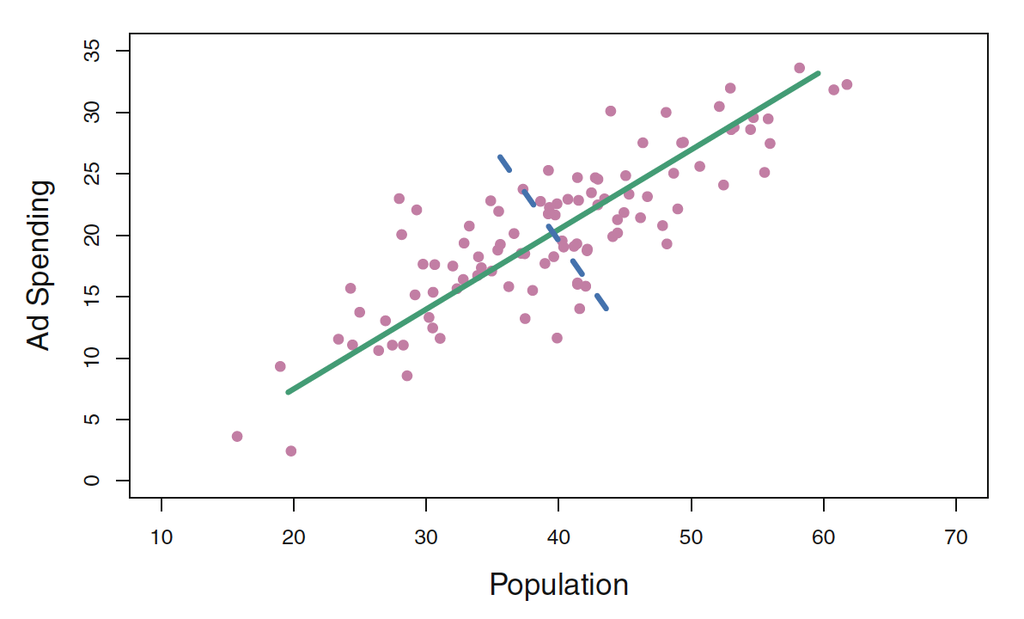

## PCA Example - Ad spending (II)

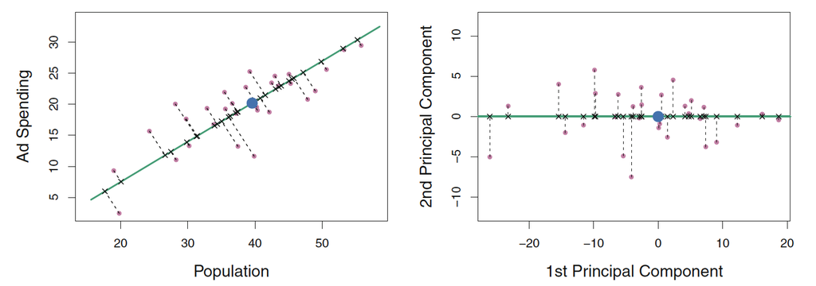

## PCA Example - Ad spending (III)

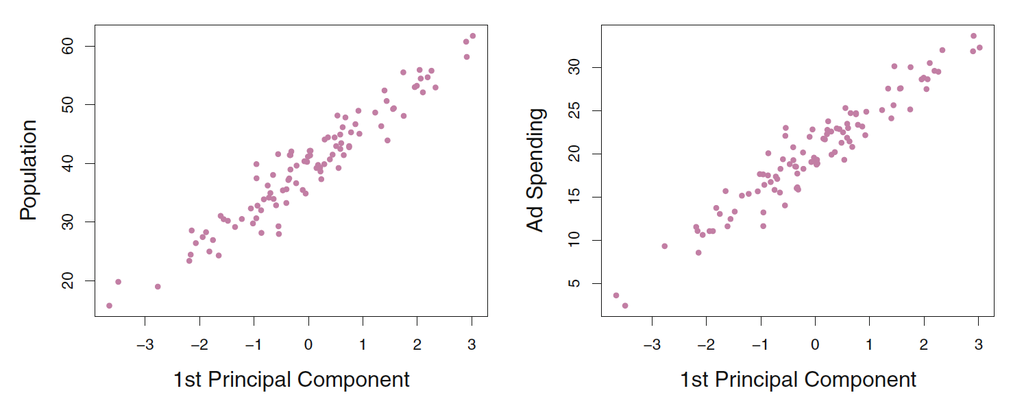

## PCA Example - Ad spending (IV)

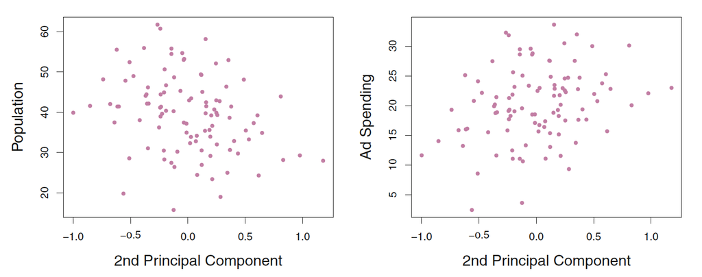

## PCA - Overview

- Principal component analysis (PCA) is a dimensionality reduction technique
  - Our ability to visualize data is limited to 2 or 3 dimensions.

## PCA - Overview

- Principal component analysis (PCA) is a dimensionality reduction technique
  - Our ability to visualize data is limited to 2 or 3 dimensions.
  - Lower dimension can reduce numerical algorithms computational time.

## PCA - Overview

- Principal component analysis (PCA) is a dimensionality reduction technique
  - Our ability to visualize data is limited to 2 or 3 dimensions.
  - Lower dimension can reduce numerical algorithms computational time.
  - Many statistical models suffer from high correlation between covariates

## PCA - Overview

- Principal component analysis (PCA) is a dimensionality reduction technique
  - Our ability to visualize data is limited to 2 or 3 dimensions.
  - Lower dimension can reduce numerical algorithms computational time.
  - Many statistical models suffer from high correlation between covariates
- PCA is not scale invariant,
  - standardize all the \(p\) variables before applying PCA.

## PCA - Overview

- Principal component analysis (PCA) is a dimensionality reduction technique
  - Our ability to visualize data is limited to 2 or 3 dimensions.
  - Lower dimension can reduce numerical algorithms computational time.
  - Many statistical models suffer from high correlation between covariates
- PCA is not scale invariant,
  - standardize all the \(p\) variables before applying PCA.
- Assume \(\boldsymbol \Sigma\) to be the covariance matrix associated with \(\boldsymbol X\).
  - The fraction of the original variance kept by the \(M\) principal component

\[ R^2 = \frac{\sum _{i=1}^{M} \lambda _i}{\sum _{j=1}^{p}\lambda _j}, \quad \lambda_i's \text{ eigenvalues of } \boldsymbol \Sigma\]

## Recommended exercise 7

How many principal components should we use for the Credit Dataset? Justify?

## Principal Components Regression (PCR)

## Principal Components Regression (PCR)

- Principal Components Regression involves:
  - Constructing the first \(M\) principal components \(\boldsymbol Z_1, ..., \boldsymbol Z_M\)
  - Using these components as the predictors in a standard linear regression model

## Principal Components Regression (PCR)

- Principal Components Regression involves:
  - Constructing the first \(M\) principal components \(\boldsymbol Z_1, ..., \boldsymbol Z_M\)
  - Using these components as the predictors in a standard linear regression model
- Key assumptions: A small number of principal components suffice to explain:
  1. Most of the variability in the data.
  2. The relationship with the response.

## Principal Components Regression (PCR)

- Principal Components Regression involves:
  - Constructing the first \(M\) principal components \(\boldsymbol Z_1, ..., \boldsymbol Z_M\)
  - Using these components as the predictors in a standard linear regression model
- Key assumptions: A small number of principal components suffice to explain:
  1. Most of the variability in the data.
  2. The relationship with the response.
- The assumptions above are not guaranteed to hold in every case.
  - This is true specially for assumption \(2\) above.
  - Since the PCs are selected via unsupervised learning.

## Example: PCR vs. Lasso and Ridge (Simulated data)

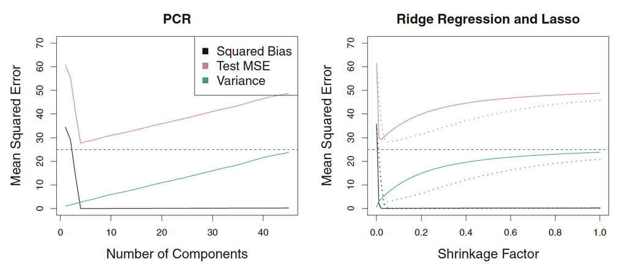

## Example: PCR vs. Lasso and Ridge (Simulated data)

- PCR performed well on simulated data, recovering the need for \(M=5\)
  - However, results are only slightly better than lasso and very similar to Ridge.

## Example: PCR vs. Lasso and Ridge (Simulated data)

- PCR performed well on simulated data, recovering the need for \(M=5\)
  - However, results are only slightly better than lasso and very similar to Ridge.
- Similar to Ridge, PCR does not perform feature selection
  - PCs are linear combination of all predictors

## Example: PCR vs. Lasso and Ridge (Simulated data)

- PCR performed well on simulated data, recovering the need for \(M=5\)
  - However, results are only slightly better than lasso and very similar to Ridge.
- Similar to Ridge, PCR does not perform feature selection
  - PCs are linear combination of all predictors
- PCR can be seen as discretized version of Ridge regression.
  - Ridge shrinks coefs. of the PCs by \(\lambda_j^2/(\lambda_j^2 + \lambda)\)
  - Higher pressure on less important PCs
  - PCR discards the \(p - M\) smallest eigenvalue components.

## Example: Shrinkage Factor

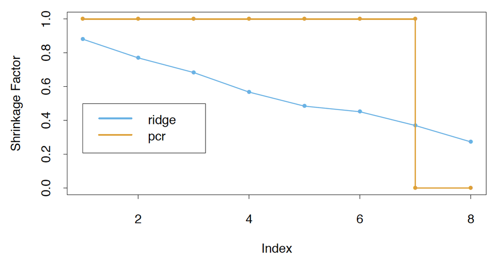

## Example: PCR (Credit Data)

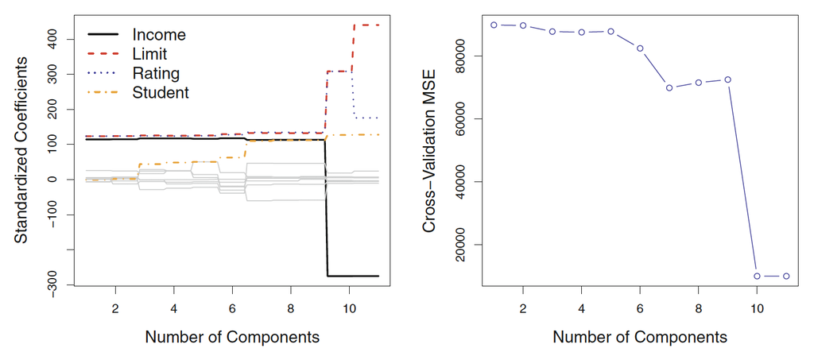

## Recommended exercise 11

Apply PCR on the Credit dataset and compare the results with the methods covered in Lecture 1.

## PCR (Drawback)

- Dimensionality reduction is done via an unsurpevised method (PCA)
  - No guarantee that the directions that best explain the predictors will also be the best directions to use for predicting the response.

## Partial Least Squares (PLS)

## Partial Least Squares (PLS)

- PLS works similar to PCR
  - Dimension reduction: \(Z_1, ..., Z_M\), \(M < p\)
  - \(Z_i\) linear combination of original predictors.
  - Apply standard linear model using \(Z_1, ..., Z_M\) as predictors.

## Partial Least Squares (PLS)

- PLS works similar to PCR
  - Dimension reduction: \(Z_1, ..., Z_M\), \(M < p\)
  - \(Z_i\) linear combination of original predictors.
  - Apply standard linear model using \(Z_1, ..., Z_M\) as predictors.
- But it uses the response \(Y\) in order to identify new features
  - attempts to find directions that help explain both the response and the predictors.

## Partial Least Squares (Algorithm)

- \(Z_1 = \sum _{i=1}^p \phi_{j1} X_j\)
  - \(\phi_{j1}\) is the coefficient from the simple linear regression of \(Y\) onto \(X_j\).
  - this coefficient is proportional to the correlation between \(Y\) and \(X_j\).
  - PLS puts highest weight on the variables that are most strongly related to the response.

## Partial Least Squares (Algorithm)

- \(Z_1 = \sum _{i=1}^p \phi_{j1} X_j\)
  - \(\phi_{j1}\) is the coefficient from the simple linear regression of \(Y\) onto \(X_j\).
  - this coefficient is proportional to the correlation between \(Y\) and \(X_j\).
  - PLS puts highest weight on the variables that are most strongly related to the response.
- To obtain the second PLS direction, \(Z_2\):
  - We regress each variable on \(Z_1\) and take the residuals
  - The residuals are remained info not explained by \(Z_1\)
  - We the compute \(Z_2\) using this orthogonalized data, similarly to \(Z_1\).

## Partial Least Squares (Algorithm)

- \(Z_1 = \sum _{i=1}^p \phi_{j1} X_j\)
  - \(\phi_{j1}\) is the coefficient from the simple linear regression of \(Y\) onto \(X_j\).
  - this coefficient is proportional to the correlation between \(Y\) and \(X_j\).
  - PLS puts highest weight on the variables that are most strongly related to the response.
- To obtain the second PLS direction, \(Z_2\):
  - We regress each variable on \(Z_1\) and take the residuals
  - The residuals are remained info not explained by \(Z_1\)
  - We the compute \(Z_2\) using this orthogonalized data, similarly to \(Z_1\).
- We can repeat this iteration process \(M\) times to get \(Z_1, ..., Z_M\).

## Recommended exercise 12

Apply PLS on the Credit dataset and compare the results with the methods covered in Lecture 1 and PCR.

## Partial Least Squares (Performance)

- In practice, PLS often performs no better than ridge regression or PCR.
  - Supervised dimension reduction of PLS can reduce bias.
  - It also has the potential to increase variance.

## In summary

- PLS, PCR and ridge regression tend to behave similarly.

## In summary

- PLS, PCR and ridge regression tend to behave similarly.
- Ridge regression may be preferred because it shrinks smoothly, rather than in discrete steps.

## In summary

- PLS, PCR and ridge regression tend to behave similarly.
- Ridge regression may be preferred because it shrinks smoothly, rather than in discrete steps.
- Lasso falls somewhere between ridge regression and best subset regression, and enjoys some of the properties of each.

## Considerations in high dimensions

## High dimension

- High dimension problems: \(n < p\)
- More common nowadays

## High dimension issues (Example)

- Standard linear regression cannot be applied.
  - Perfect fit to the data, regardless of relationship
  - Unfortunately, the \(C_p\), AIC, and BIC approaches are problematic (hard to estimate \(\sigma^2\))

## High dimension issues (Example)

- Standard linear regression cannot be applied.
  - Perfect fit to the data, regardless of relationship
  - Unfortunately, the \(C_p\), AIC, and BIC approaches are problematic (hard to estimate \(\sigma^2\))

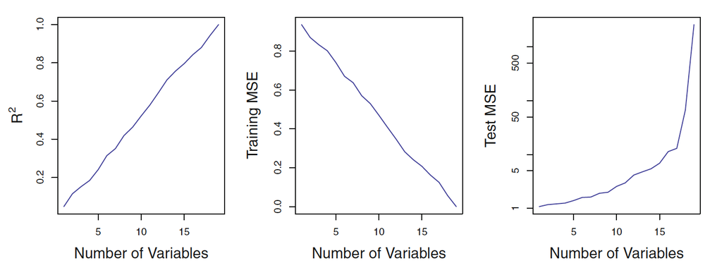

## Noise predictors

- The test error tends to increase as the dimensionality of the problem
  - Unless the additional features are truly associated with the response.

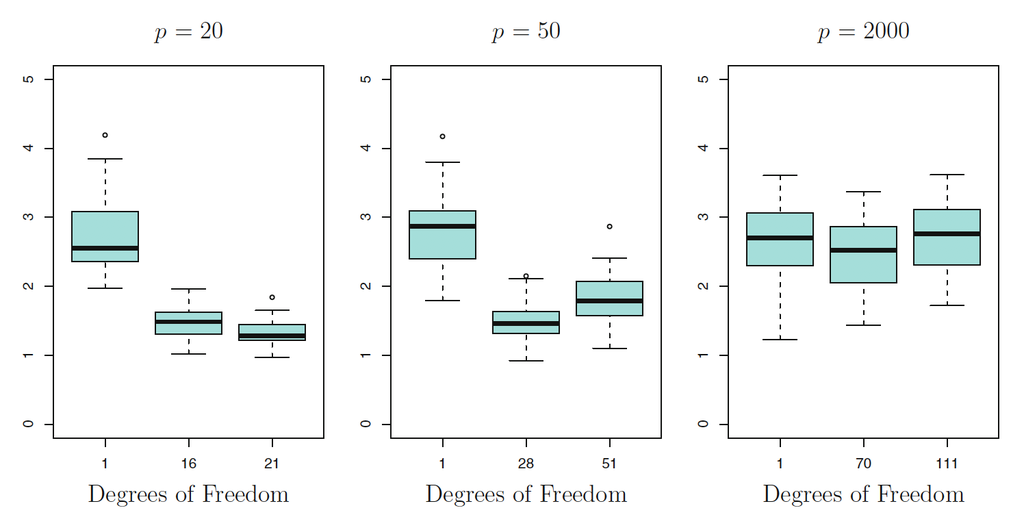

## The danger of too many features

- In general, adding additional signal features helps (smaller test set errors)

## The danger of too many features

- In general, adding additional signal features helps (smaller test set errors)
- However, adding noise features that are not truly associated with the response increases test set error.
  - Noise features exacerbating the risk of overfitting
  - Previous example shows that regularizations does not eliminate the problem

## The danger of too many features

- In general, adding additional signal features helps (smaller test set errors)
- However, adding noise features that are not truly associated with the response increases test set error.
  - Noise features exacerbating the risk of overfitting
  - Previous example shows that regularizations does not eliminate the problem
- New technologies that allow for the collection of measurements for thousands or millions of features are a double-edged sword

## Interpreting results in high dimension

- In the high-dimensional setting, the multicollinearity problem is extreme

## Interpreting results in high dimension

- In the high-dimensional setting, the multicollinearity problem is extreme
- Essentially, this means:
  - We can never know exactly which variables (if any) truly are predictive of the outcome.
  - We can never identify the best coefficients for use in the regression.

## Interpreting results in high dimension

- In the high-dimensional setting, the multicollinearity problem is extreme
- Essentially, this means:
  - We can never know exactly which variables (if any) truly are predictive of the outcome.
  - We can never identify the best coefficients for use in the regression.
  - At most, we can hope to assign large regression coefficients to variables that are correlated with the variables that truly arec predictive of the outcome.
  - We will find one of possibly many suitable predictive models.

## The end

**Thank you for showing up**